Session 6: Multilevel Data  
DSOM 5509: Applied Statistical Methods  
Brian S. Anderson, Ph.D.  
Associate Professor  
Department of Global Entrepreneurship & Innovation  
andersonbri@umkc.edu

[figure not shown]

© 2019 Brian S. Anderson

**Plan of the Day**

- Individual Paper (Due 30 March) and Gradebook Review
- Advance Work Review
- Session 5 Team Deliverable Review
- Working with Multilevel Data
- Session 6 Team Deliverable

**Advance Work Review**

[figure not shown]

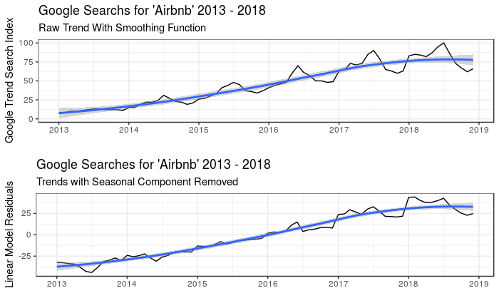

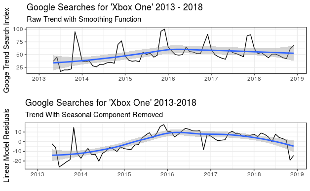

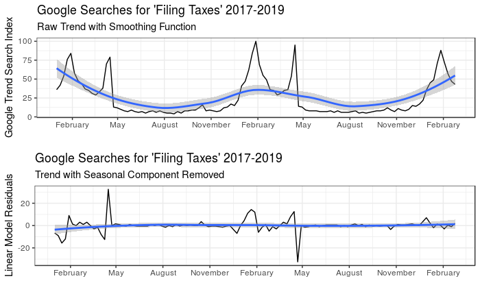

[figure not shown]

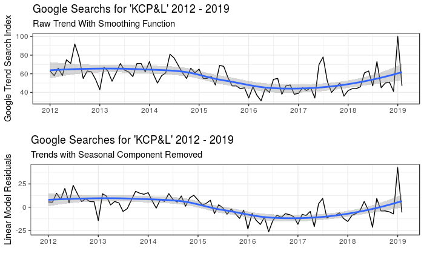

**Session 5 Team Deliverable Review**

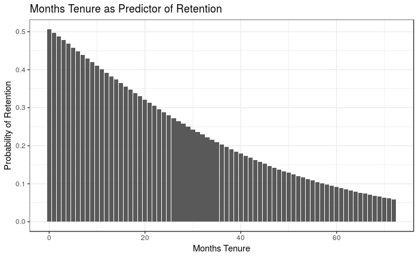

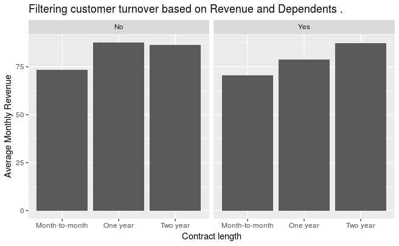

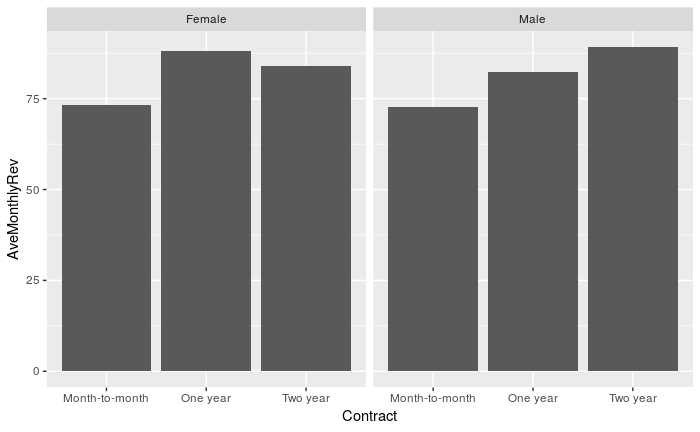

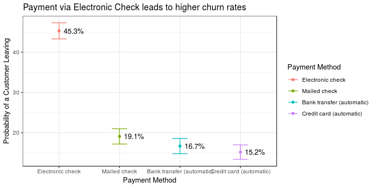

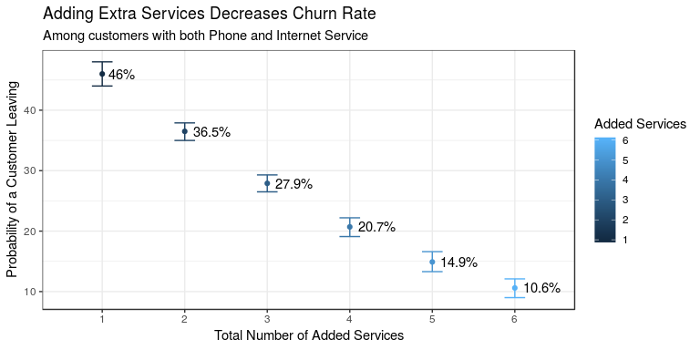

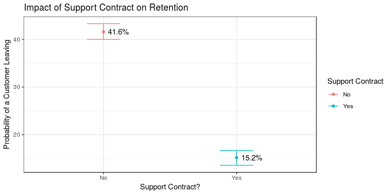

**Multilevel Madness!**

```r
library(tidyverse)
rnd.df <- read_csv("FirmRND.csv")
rnd.df
```

```
## # A tibble: 330 x 9
##    FirmID  Year TickerSymbol CompanyName SICCode    RND Revenue     at
##     <dbl> <dbl> <chr>        <chr>         <dbl>  <dbl>   <dbl>  <dbl>
##  1   1820  2013 ALOT         ASTRONOVA …    3577 5.07e0    68.6 7.80e1
##  2   1820  2014 ALOT         ASTRONOVA …    3577 5.80e0    88.3 7.43e1
##  3   1820  2015 ALOT         ASTRONOVA …    3577 6.94e0    94.7 7.80e1
##  4   1820  2016 ALOT         ASTRONOVA …    3577 6.31e0    98.4 8.37e1
##  5   1820  2017 ALOT         ASTRONOVA …    3577 7.45e0   113.  1.22e2
##  6   2721  2013 CAJ          CANON INC      3577 2.91e3 35453.  4.03e4
##  7   2721  2014 CAJ          CANON INC      3577 2.58e3 31099.  3.72e4
##  8   2721  2015 CAJ          CANON INC      3577 2.73e3 31598.  3.68e4
##  9   2721  2016 CAJ          CANON INC      3577 2.59e3 29127.  4.40e4
## 10   2721  2017 CAJ          CANON INC      3577 2.93e3 36206.  4.61e4
## # … with 320 more rows, and 1 more variable: NetIncome <dbl>
```

Wrangling…

```r
# Industries...
# 3570 - Computer & Office Eqpmt
# 3571 - Electronic Computers
# 3572 - Computer Storage Devices
# 3576 - Computer Communications Eqpmt
# 3577 - Computer Peripheral Eqpmt
# 3578 - Calculating & Accounting Machines
# 3579 - Office Machines

rnd.df <- rnd.df %>%
  mutate(SICCode = factor(SICCode))
```

What are we looking at?

```r
rnd.df %>%
  summarise(NumberFirms = n_distinct(FirmID))
```

```
## # A tibble: 1 x 1
##   NumberFirms
##         <int>
## 1          79
```

```r
rnd.df %>%
  distinct(Year)
```

```
## # A tibble: 5 x 1
##    Year
##   <dbl>
## 1  2013
## 2  2014
## 3  2015
## 4  2016
## 5  2017
```

```r
rnd.df %>%
  count(SICCode)
```

```
## # A tibble: 7 x 2
##   SICCode     n
##   <fct>   <int>
## 1 3570       15
## 2 3571       22
## 3 3572       46
## 4 3576      121
## 5 3577       88
## 6 3578       28
## 7 3579       10
```

Lets create a couple of variables…

```r
rnd.df <- rnd.df %>%
  mutate(ROS = 100 * (NetIncome / Revenue),
         RNDIntensity = 100 * (RND / Revenue))
```

And now a visualization…

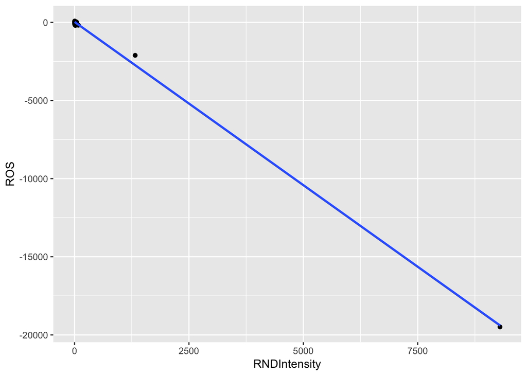

```r
ggplot(data = rnd.df, aes(y = ROS, x = RNDIntensity)) +
  geom_point() +
  geom_smooth(method = "lm")
```

What to do about outliers…

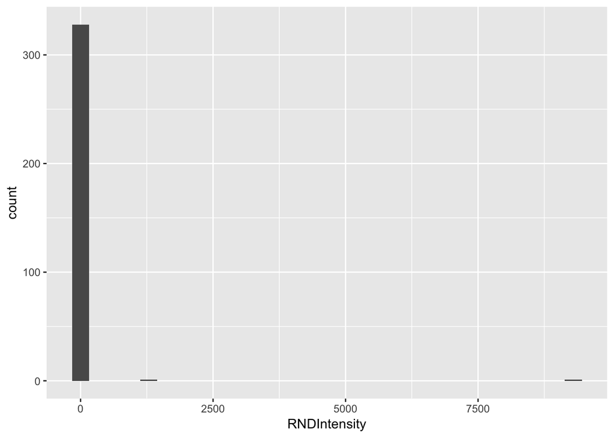

```r
ggplot(data = rnd.df, aes(x = RNDIntensity)) +
  geom_histogram()
```

```r
rnd.df %>%
  filter(RNDIntensity > 100)
```

```
## # A tibble: 2 x 11
##   FirmID  Year TickerSymbol CompanyName SICCode   RND Revenue    at
##    <dbl> <dbl> <chr>        <chr>       <fct>   <dbl>   <dbl> <dbl>
## 1 300107  2016 NNDM         NANO DIMEN… 3577     4.28   0.046  22.2
## 2 300107  2017 NNDM         NANO DIMEN… 3577    11.4    0.86   21.5
## # … with 3 more variables: NetIncome <dbl>, ROS <dbl>, RNDIntensity <dbl>
```

Why does it matter?

```r
summary(lm(ROS ~ RNDIntensity, data = rnd.df))
```

```
##
## Call:
## lm(formula = ROS ~ RNDIntensity, data = rnd.df)
##
## Residuals:
##     Min      1Q  Median      3Q     Max
## -187.24  -14.26   -2.32   13.07  628.90
##
## Coefficients:
##               Estimate Std. Error t value Pr(>|t|)
## (Intercept)  26.713906   2.512006   10.63   <2e-16 ***
## RNDIntensity -2.088763   0.004856 -430.17   <2e-16 ***
## ---
## Signif. codes:  0 '***' 0.001 '**' 0.01 '*' 0.05 '.' 0.1 ' ' 1
##
## Residual standard error: 45.44 on 328 degrees of freedom
## Multiple R-squared:  0.9982, Adjusted R-squared:  0.9982
## F-statistic: 1.85e+05 on 1 and 328 DF,  p-value: < 2.2e-16
```

```r
rnd_filter.df <- rnd.df %>%
  filter(RNDIntensity <= 100)

summary(lm(ROS ~ RNDIntensity, data = rnd_filter.df))
```

```
##
## Call:
## lm(formula = ROS ~ RNDIntensity, data = rnd_filter.df)
##
## Residuals:
##      Min       1Q   Median       3Q      Max
## -187.934   -5.430    1.415   12.315   78.767
##
## Coefficients:
##              Estimate Std. Error t value Pr(>|t|)
## (Intercept)    10.583      2.553   4.145 4.34e-05 ***
## RNDIntensity   -1.132      0.137  -8.264 3.60e-15 ***
## ---
## Signif. codes:  0 '***' 0.001 '**' 0.01 '*' 0.05 '.' 0.1 ' ' 1
##
## Residual standard error: 26.95 on 326 degrees of freedom
## Multiple R-squared:  0.1732, Adjusted R-squared:  0.1707
## F-statistic: 68.29 on 1 and 326 DF,  p-value: 3.605e-15
```

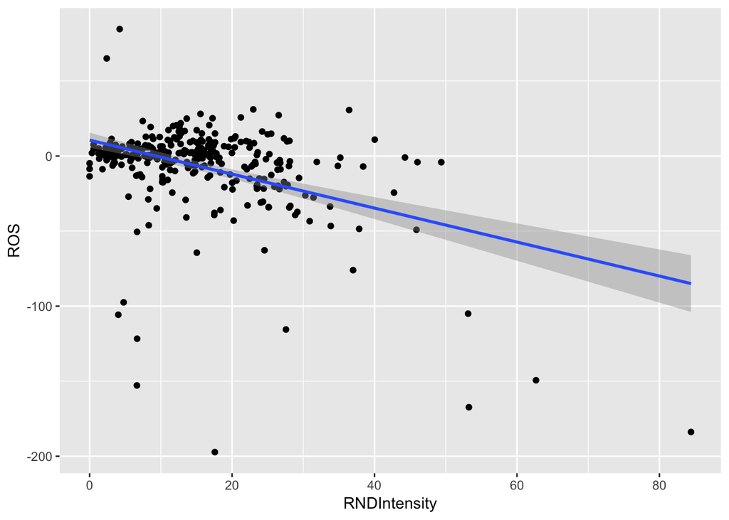

```r
ggplot(data = rnd_filter.df, aes(y = ROS, x = RNDIntensity)) +
  geom_point() +
  geom_smooth(method = "lm")
```

```r
rnd_filter.df <- rnd_filter.df %>%
  filter(ROS >= -100)

summary(lm(ROS ~ RNDIntensity, data = rnd_filter.df))
```

```
##
## Call:
## lm(formula = ROS ~ RNDIntensity, data = rnd_filter.df)
##
## Residuals:
##      Min       1Q   Median       3Q      Max
## -100.256   -6.616    1.118    7.699   81.487
##
## Coefficients:
##              Estimate Std. Error t value Pr(>|t|)
## (Intercept)    5.4338     1.7669   3.075  0.00228 **
## RNDIntensity  -0.5559     0.1018  -5.461 9.56e-08 ***
## ---
## Signif. codes:  0 '***' 0.001 '**' 0.01 '*' 0.05 '.' 0.1 ' ' 1
##
## Residual standard error: 17.11 on 317 degrees of freedom
## Multiple R-squared:  0.086,  Adjusted R-squared:  0.08311
## F-statistic: 29.83 on 1 and 317 DF,  p-value: 9.563e-08
```

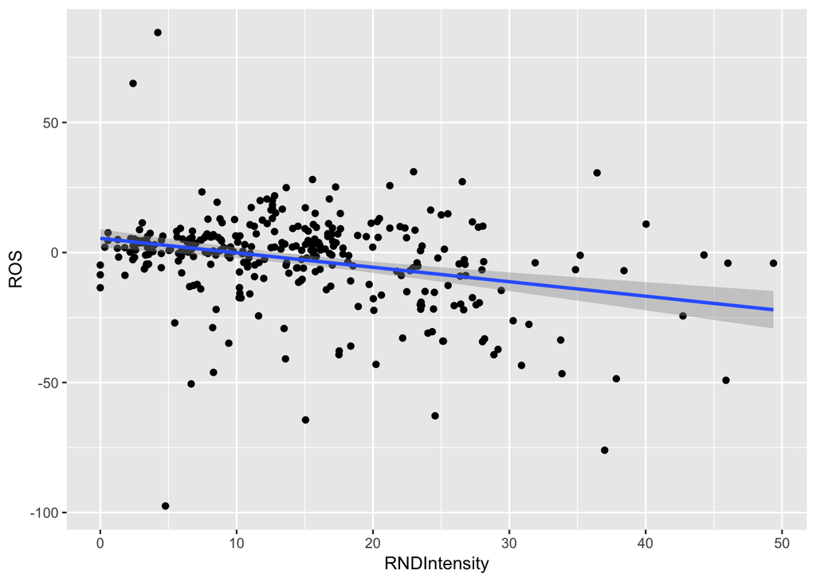

```r
ggplot(data = rnd_filter.df, aes(y = ROS, x = RNDIntensity)) +
  geom_point() +
  geom_smooth(method = "lm")
```

Be careful when you filter out outliers…

Side note…

*Panel data* is a type of multilevel data with repeated measure of an entity over time. One of the handy things you can do is to incorporate *temporal sequencing* into your model.

```r
lag.df <- rnd_filter.df %>%
  group_by(FirmID) %>%
    mutate(lagRNDIntensity = lag(RNDIntensity))

lag.df %>%
  select(FirmID, RNDIntensity, lagRNDIntensity)
```

```
## # A tibble: 319 x 3
## # Groups:   FirmID [78]
##    FirmID RNDIntensity lagRNDIntensity
##     <dbl>        <dbl>           <dbl>
##  1   1820         7.39           NA
##  2   1820         6.57            7.39
##  3   1820         7.34            6.57
##  4   1820         6.41            7.34
##  5   1820         6.57            6.41
##  6   2721         8.21           NA
##  7   2721         8.29            8.21
##  8   2721         8.64            8.29
##  9   2721         8.89            8.64
## 10   2721         8.09            8.89
## # … with 309 more rows
```

```r
summary(lm(ROS ~ lagRNDIntensity, data = lag.df))
```

```
##
## Call:
## lm(formula = ROS ~ lagRNDIntensity, data = lag.df)
##
## Residuals:
##     Min      1Q  Median      3Q     Max
## -67.048  -5.938   1.857   7.689  62.245
##
## Coefficients:
##                 Estimate Std. Error t value Pr(>|t|)
## (Intercept)       3.9195     1.8677   2.099   0.0369 *
## lagRNDIntensity  -0.4581     0.1094  -4.188 3.96e-05 ***
## ---
## Signif. codes:  0 '***' 0.001 '**' 0.01 '*' 0.05 '.' 0.1 ' ' 1
##
## Residual standard error: 15.91 on 239 degrees of freedom
##   (78 observations deleted due to missingness)
## Multiple R-squared:  0.06837,    Adjusted R-squared:  0.06447
## F-statistic: 17.54 on 1 and 239 DF,  p-value: 3.959e-05
```

What we just looked at is called a *pooled model*. It ignores the multilevel structure of the data.

Very rarely is it appropriate to model multilevel data with a pooled model.

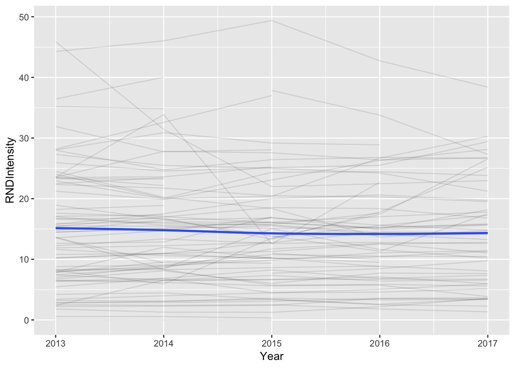

```r
ggplot(rnd_filter.df, aes(y = RNDIntensity, x = Year)) +
  geom_line(aes(group = FirmID), alpha = 1/10) +
  geom_smooth(method = "loess", se = FALSE)
```

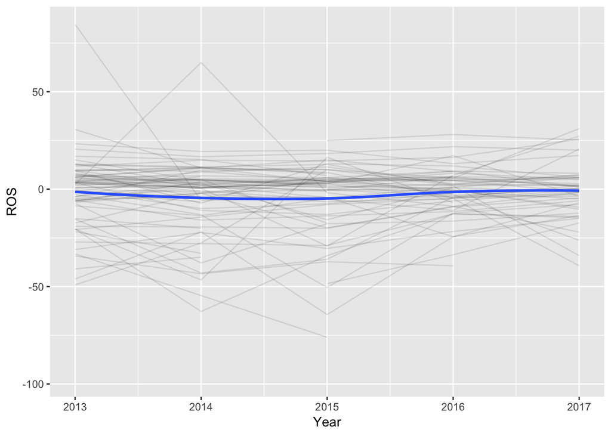

```r
ggplot(rnd_filter.df, aes(y = ROS, x = Year)) +
  geom_line(aes(group = FirmID), alpha = 1/10) +
  geom_smooth(method = "loess", se = FALSE)
```

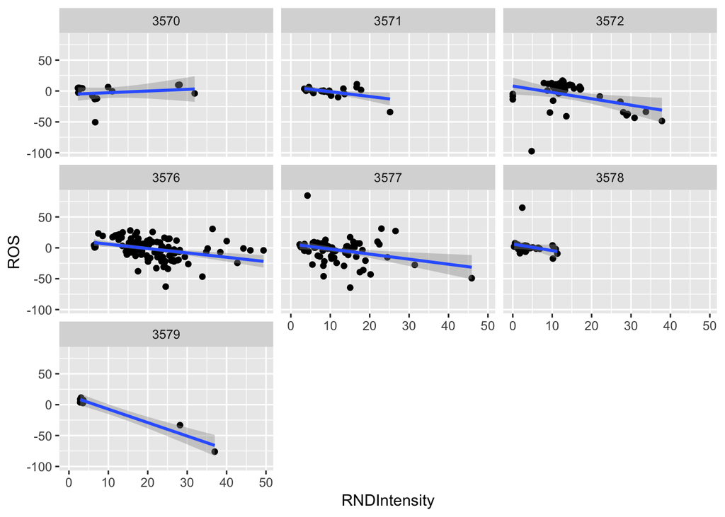

```r
ggplot(rnd_filter.df, aes(y = ROS, x = RNDIntensity)) +
  geom_point() +
  geom_smooth(method = "lm") +
  facet_wrap(~ SICCode)
```

$$y_{ij} = \beta_{0j} + \beta_{1j}x_{ij} + \epsilon_{ij}$$

With panel data, we are looking at **two** different effects of $x$ on $y$.

- The **within** effect, which is the average effect of $x$ on $y$ for a given (average) $j$ over observations $i$
- The **between** effect, which is the average effect of $x$ on $y$ across $j's$

We can decompose $x_{ij}$ into:

$$x_{ij}=\gamma_i+\tau_{ij}$$

For each $x_{ij}$, there is going to be a between-component, $\gamma$, that never changes for each $i$ in the sample (the firm, for example). But there is also going to be a within-component, $\tau$, that can change for each $\gamma$ over $i$ (the firm’s sales over time, for example).

$$y = \alpha + \beta{x} + \epsilon$$

By ignoring the multilevel structure with a pooled model, we are violating something called the *i.i.d.* assumption.

Given that each $i$ occurs as a function of the $j$ it nests under, we assume that there is some type of *clustering* of each $i$ around its respective $j$. If this is true, then our OLS estimator will be inconsistent.

So we have to use a different approach, and the choice depends on a couple of things…

- The structure of the data
- Whether we are interested in *within* effects, *betweeen* effects, or both
- Whether meaningful predictors exist at multiple levels ($i$ and $j$)
- The relationship between $i$’s and their corresponding $j$’s

*The relationship between $i$’s and their corresponding $j$’s*

This part is the hardest. Particularly when *unobserved* variables at the $i$ level correlates with their $j$.

Just like our other omitted variable problems, if we don’t capture all of the meaningful variables that might cause $i$’s to correlate with their $j$’s, our model will produce biased results.

Fortunately in multilevel data, there are some shortcuts to help us deal with this source of bias.

Correctly modeling multilevel data is, well, hard.

We’re going to jump right in with something called a Random Intercept/Random Slope Within-Between Multilevel Model.

**Level 1**
$$y_{ij} = \beta_{0j} + \beta_{1j}x_{ij} + \epsilon_{ij}$$

- $y_{ij}$ = Value of the $i^{th}$ observation of $y$ for the $j^{th}$ entity
- $\beta_{0j}$ = The value of $y$ (intercept) for the $j^{th}$ entity
- $\beta_{1j}$ = The expected change in $y$ (slope) for a one unit change in $x$ for the $j^{th}$ entity
- $x$ = Value of the $i^{th}$ observation of $x$ for the $j^{th}$ entity
- $\epsilon_{ij}$ = The variance in the $i^{th}$ observation of $y$ for the $j^{th}$ entity that is not explained by the Level 1 equation (sometimes called $r_{ij}$)

**Level 2**

$$\beta_{0j} = \gamma_{00} + u_{0j}$$

- $\gamma_{00}$ = The overall intercept, also called the *grand mean*; the expected value of $y$ for all $i,j$ observations when all Level 1 and Level 2 predictors equal zero
- $u_{0j}$ = The deviation in the intercept for the $j^{th}$ entity from the overall intercept ($\gamma_{00}$)

$$\beta_{1j} = \gamma_{10} + u_{1j}$$

- $\gamma_{10}$ = The expected change in $y$ for an average $j$ across observations $i$
- $u_{1j}$ = The deviation in the slope for the $j^{th}$ entity from the overall (average) slope ($\gamma_{10}$)

Fixed effects, random effects, and the difference between economics and, well, everyone else.

Shrinkage, partial pooling, and the benefits of using Bayesian multilevel modeling.

```r
library(rstanarm)

bayes.model <- stan_glmer(ROS ~ RNDIntensity +
                            (RNDIntensity | FirmID),
                          data = rnd_filter.df,
                          seed = 1, refresh = 0, chains = 1)

baseline.model
```

Fair warning, the model will take a little bit. Remember when I said that the math behind fitting Bayesian models is complicated? If it’s taking your computer this long, imagine doing it by hand!

Ok, we’re going to switch back to frequentist statistics, because it will take too long!

```r
library(lme4)
base.model <- lmer(ROS ~ RNDIntensity + (RNDIntensity | FirmID),
                   data = rnd_filter.df)
```

```r
summary(base.model)
```

```
## Linear mixed model fit by REML ['lmerMod']
## Formula: ROS ~ RNDIntensity + (RNDIntensity | FirmID)
##    Data: rnd_filter.df
##
## REML criterion at convergence: 2590.2
##
## Scaled residuals:
##     Min      1Q  Median      3Q     Max
## -3.5566 -0.2664  0.0365  0.3734  6.6656
##
## Random effects:
##  Groups   Name         Variance Std.Dev. Corr
##  FirmID   (Intercept)  609.215  24.68
##           RNDIntensity   1.322   1.15    -0.86
##  Residual              109.394  10.46
## Number of obs: 319, groups:  FirmID, 78
##
## Fixed effects:
##              Estimate Std. Error t value
## (Intercept)    9.6291     3.9183   2.457
## RNDIntensity  -0.8024     0.2187  -3.668
##
## Correlation of Fixed Effects:
##             (Intr)
## RNDIntensty -0.883
```

In multilevel models, what we are really after is understanding different types of variance occurring at different levels.

We’re trying to quantity uncertainty around the effect of $x$ on $y$ that is because of differences within and between $j$ groups.

**Variances**

- $\sigma^2$ = Estimated within-group variance ($\epsilon_{ij}$)
- $\tau_{00}$ = Estimated between-group variance ($u_{0j}$)
- $\tau_{11}$ = Estimated random-slope variance ($u_{1j}$)
- $\rho_{01}$ = Estimated random-intercept / random-slope correlation
- ICC = Inter-class correlation coefficient

The ICC is pretty useful…it tells you the extent to which, on average, observations within a $j$ correlate with each other.

The higher the ICC, the “more important” the multilevel structure.

```r
library(sjPlot)
tab_model(base.model)
```

|  | ROS |  |  |
| --- | --- | --- | --- |
| Predictors | Estimates | CI | p |
| (Intercept) | 9.63 | 1.95 – 17.31 | **0.014** |
| RND Intensity | -0.80 | -1.23 – -0.37 | **<0.001** |
| Random Effects |  |  |  |
| σ<sup>2</sup> | 109.39 |  |  |
| τ<sub>00</sub> <sub>FirmID</sub> | 609.21 |  |  |
| τ<sub>11</sub> <sub>FirmID.RNDIntensity</sub> | 1.32 |  |  |
| ρ<sub>01</sub> <sub>FirmID</sub> | -0.86 |  |  |
| ICC <sub>FirmID</sub> | 0.85 |  |  |
| Observations | 319 |  |  |
| Marginal R<sup>2</sup> / Conditional R<sup>2</sup> | 0.124 / 0.762 |  |  |

Remember we said that each $x_{ij}$ has a within and between component? Well, so does $\beta{x}_{ij}$…

```r
tab_model(base.model, terms = c("RNDIntensity"))
```

|  | ROS |  |  |
| --- | --- | --- | --- |
| Predictors | Estimates | CI | p |
| RND Intensity | -0.80 | -1.23 – -0.37 | **<0.001** |
| Random Effects |  |  |  |
| σ<sup>2</sup> | 109.39 |  |  |
| τ<sub>00</sub> <sub>FirmID</sub> | 609.21 |  |  |
| τ<sub>11</sub> <sub>FirmID.RNDIntensity</sub> | 1.32 |  |  |
| ρ<sub>01</sub> <sub>FirmID</sub> | -0.86 |  |  |
| ICC <sub>FirmID</sub> | 0.85 |  |  |
| Observations | 319 |  |  |
| Marginal R<sup>2</sup> / Conditional R<sup>2</sup> | 0.124 / 0.762 |  |  |

So that’s hard to interpret. Fortunately with a little wrangling, we can split the within and between components of $x$, and in the process, deal with a major omitted variable concern.

We’re going to do something called *group mean centering*.

```r
rnd_filter.df <- rnd_filter.df %>%
  group_by(FirmID) %>%
    mutate(meanRNDIntensity = mean(RNDIntensity),
           cenRNDIntensity = RNDIntensity - meanRNDIntensity)
```

The `meanRNDIntensity` variable is called *panel invariant*, because it takes on the same value for all of $j$’s observations…

```r
rnd_filter.df %>%
  filter(FirmID == 1820) %>%
  select(cenRNDIntensity, meanRNDIntensity)
```

```
## # A tibble: 5 x 3
## # Groups:   FirmID [1]
##   FirmID cenRNDIntensity meanRNDIntensity
##    <dbl>           <dbl>            <dbl>
## 1   1820           0.538             6.86
## 2   1820          -0.290             6.86
## 3   1820           0.480             6.86
## 4   1820          -0.443             6.86
## 5   1820          -0.285             6.86
```

The `cenRNDIntensity` variable has a mean of 0 within each $j$, which makes each observation a deviation from the meanRNDIntensity variable.

```r
rnd_filter.df %>%
  filter(FirmID == 1820) %>%
  summarise(myMean = mean(cenRNDIntensity))
```

```
## # A tibble: 1 x 2
##   FirmID    myMean
##    <dbl>     <dbl>
## 1   1820 -3.55e-16
```

So now lets fit a new model…

```r
library(lme4)
wb.model <- lmer(ROS ~ cenRNDIntensity + meanRNDIntensity +
                   (cenRNDIntensity + meanRNDIntensity | FirmID),
                 data = rnd_filter.df)
```

```r
tab_model(wb.model)
```

|  | ROS |  |  |
| --- | --- | --- | --- |
| Predictors | Estimates | CI | p |
| (Intercept) | 2.65 | -5.12 – 10.42 | 0.504 |
| cen RND Intensity | -1.58 | -2.34 – -0.83 | **<0.001** |
| mean RND Intensity | -0.41 | -0.87 – 0.05 | 0.082 |
| Random Effects |  |  |  |
| σ<sup>2</sup> | 104.41 |  |  |
| τ<sub>00</sub> <sub>FirmID</sub> | 517.01 |  |  |
| τ<sub>11</sub> <sub>FirmID.cenRNDIntensity</sub> | 2.07 |  |  |
| τ<sub>11</sub> <sub>FirmID.meanRNDIntensity</sub> | 1.34 |  |  |
| ρ<sub>01</sub> <sub>FirmID.cenRNDIntensity</sub> | 1.00 |  |  |
| ρ<sub>01</sub> <sub>FirmID.meanRNDIntensity</sub> | -0.86 |  |  |
| ICC <sub>FirmID</sub> | 0.83 |  |  |
| Observations | 319 |  |  |

The estimate for `cenRNDIntensity` is the *within effect*, estimating the expected change in ROS for an average firm over time.

The estimate for `meanRNDIntensity` is the *between effect*, estimating the expected change in ROS across firms and over time.

In our model, the within-firm effect seems to be a major source of the variance in ROS associated with R&D Intensity, as compared to the between-firm effect.

With WB-MEM models, we can add even more levels, but that’s for another time.

Whew!

Lets do another example. This time, we are going to look at employees nested within managers.

Even though we’re talking about people instead of time, the modeling approach is the same.

```r
training.df <- read_csv("Manager.csv")
head(training.df, 10)
```

```
## # A tibble: 10 x 7
##    ManagerID EmployeeID TestScore TrainingTime AttendedTraining
##        <dbl>      <dbl>     <dbl>        <dbl>            <dbl>
##  1         1          1        46         15                  0
##  2         1          2        45         14.5                0
##  3         1          3        33          9.5                0
##  4         1          4        46         11                  0
##  5         1          5        20          8                  0
##  6         1          6        30          9.5                0
##  7         1          7        30          9.5                0
##  8         1          8        57         13                  0
##  9         1          9        36          9.5                0
## 10         1         10        36         11                  0
## # … with 2 more variables: meanTrainingTime <dbl>, cenTrainingTime <dbl>
```

Lets specify our model…

```r
wb.ts.model <- lmer(TestScore ~ cenTrainingTime + meanTrainingTime +
                      AttendedTraining +
                      (cenTrainingTime + meanTrainingTime | ManagerID),
                    data = training.df)
```

```r
tab_model(wb.ts.model)
```

|  | Test Score |  |  |
| --- | --- | --- | --- |
| Predictors | Estimates | CI | p |
| (Intercept) | -0.02 | -29.24 – 29.19 | 0.999 |
| cen Training Time | 2.73 | 1.95 – 3.51 | **<0.001** |
| mean Training Time | 3.38 | 0.72 – 6.04 | **0.013** |
| Attended Training | -3.09 | -8.52 – 2.35 | 0.265 |
| Random Effects |  |  |  |
| σ<sup>2</sup> | 52.43 |  |  |
| τ<sub>00</sub> <sub>ManagerID</sub> | 406.96 |  |  |
| τ<sub>11</sub> <sub>ManagerID.cenTrainingTime</sub> | 0.33 |  |  |
| τ<sub>11</sub> <sub>ManagerID.meanTrainingTime</sub> | 4.37 |  |  |
| ρ<sub>01</sub> <sub>ManagerID.cenTrainingTime</sub> | 0.91 |  |  |
| ρ<sub>01</sub> <sub>ManagerID.meanTrainingTime</sub> | -1.00 |  |  |
| ICC <sub>ManagerID</sub> | 0.89 |  |  |
| Observations | 133 |  |  |
| Marginal R<sup>2</sup> / Conditional R<sup>2</sup> | 0.402 / 0.550 |  |  |

Lets take a look at the *fixed effeccts* first.

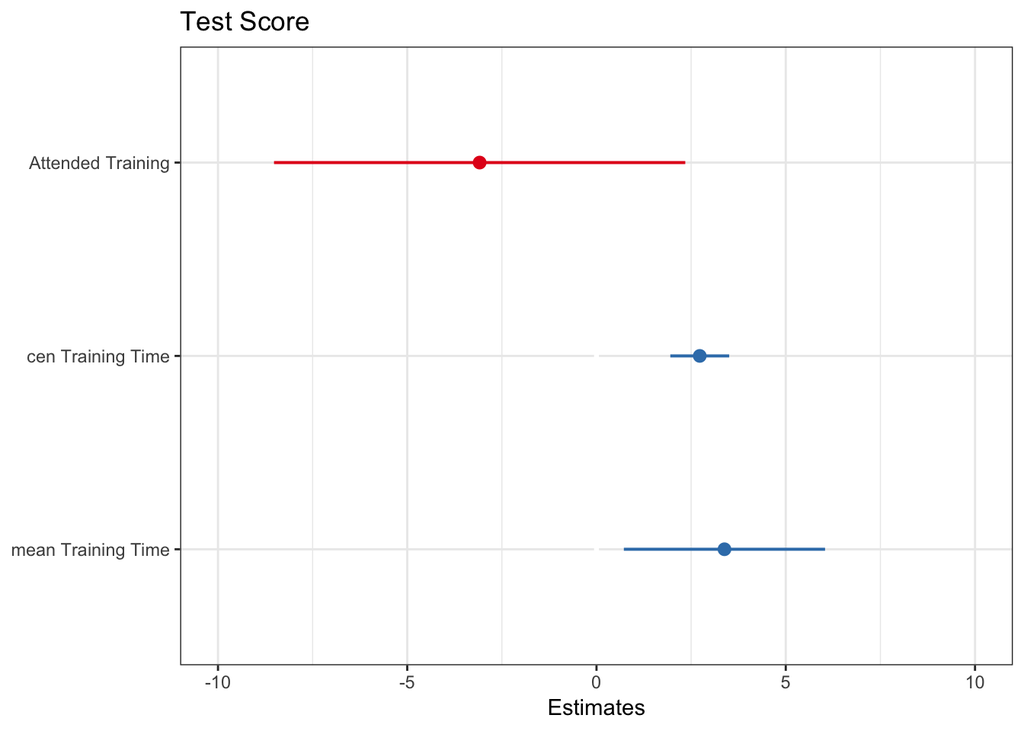

```r
plot_model(wb.ts.model) +
  theme_bw()
```

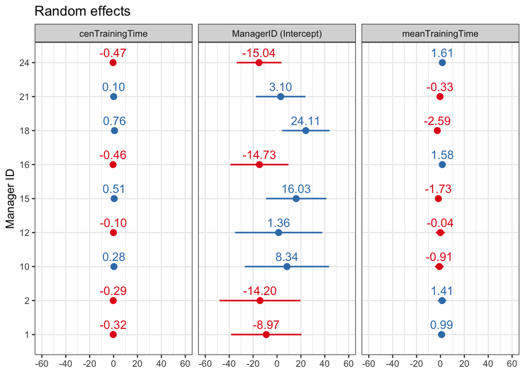

```r
plot_model(wb.ts.model, type = "re", show.values = TRUE,
           value.offset = .3) +
  labs(x = "Manager ID") +
  theme_bw()
```

**Session 6 Team Deliverable…**

Catch up and open questions!

**Remaining Questions?**

Go forth and do great things!